# Domain:-Finance

# 15.Is there a correlation between the number of credit problems and the current credit balance?

[output not shown]

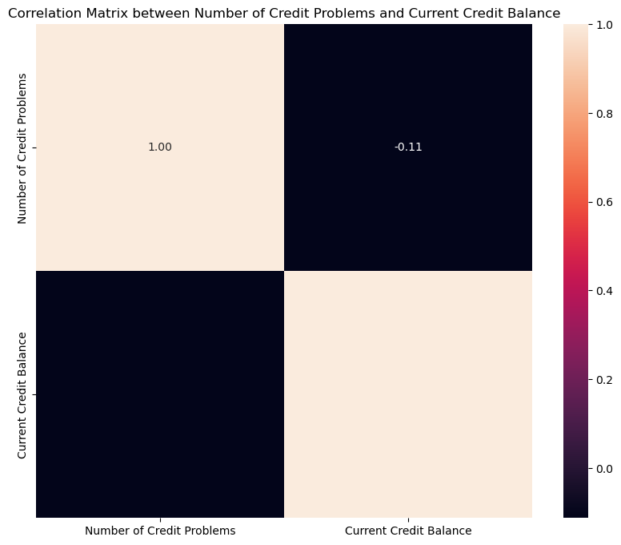

```python
correlation = df['Number of Credit Problems'].corr(df['Current Credit Balance'])
correlation_matrix = df[['Number of Credit Problems', 'Current Credit Balance']].corr()

plt.figure(figsize=(10, 8))
sns.heatmap(correlation_matrix, annot=True, fmt='.2f')
plt.title('Correlation Matrix between Number of Credit Problems and Current Credit Balance')
plt.show()
```

# 16.What is the distribution of current loan amounts across different home ownership types?

```python
print(df.columns)
```

```
Index(['Loan ID', 'Customer ID', 'Loan Status', 'Current Loan Amount', 'Term',
       'Credit Score', 'Annual Income', 'Years in current job',
       'Home Ownership', 'Purpose', 'Monthly Debt', 'Years of Credit History',
       'Months since last delinquent', 'Number of Open Accounts',
       'Number of Credit Problems', 'Current Credit Balance',
       'Maximum Open Credit', 'Bankruptcies', 'Tax Liens'],
      dtype='object')
```

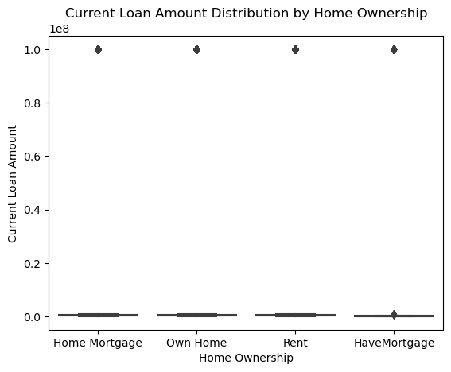

```python
sns.boxplot(data=df, x='Home Ownership', y='Current Loan Amount')
plt.title('Current Loan Amount Distribution by Home Ownership')
plt.show()
```

# 17.How does the annual income vary with the years in the current job?

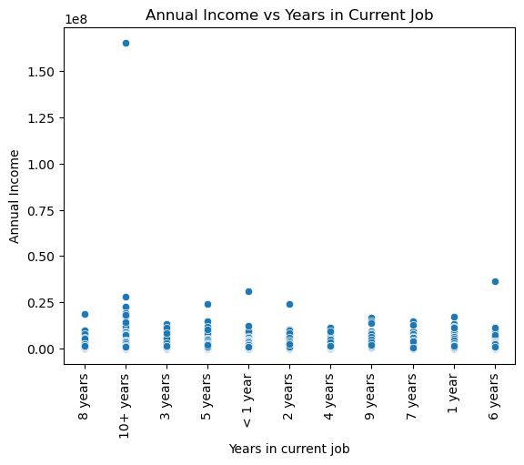

```python
sns.scatterplot(data=df, x='Years in current job', y='Annual Income')
plt.title('Annual Income vs Years in Current Job')
plt.xticks(rotation = 90)
plt.show()
```

# 18.Is there a correlation between the current loan amount and the monthly debt?

[output not shown]

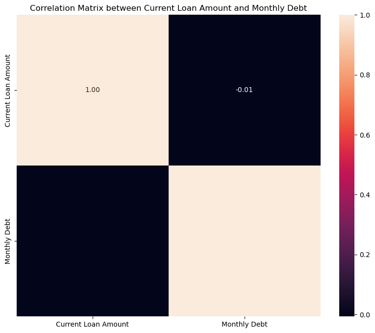

```python
correlation = df['Current Loan Amount'].corr(df['Monthly Debt'])
correlation_matrix = df[['Current Loan Amount', 'Monthly Debt']].corr()

plt.figure(figsize=(10, 8))
sns.heatmap(correlation_matrix, annot=True, fmt='.2f')
plt.title('Correlation Matrix between Current Loan Amount and Monthly Debt')
plt.show()
```

# 19.What is the average monthly debt for each home ownership type?

```python
average_debt_by_home_ownership = df.groupby('Home Ownership')['Monthly Debt'].mean()
print(average_debt_by_home_ownership)
```

```
Home Ownership
HaveMortgage     18541.776822
Home Mortgage    21072.059467
Own Home         17060.082101
Rent             15796.777284
Name: Monthly Debt, dtype: float64
```

# 20.How does the credit score vary with the number of open accounts?

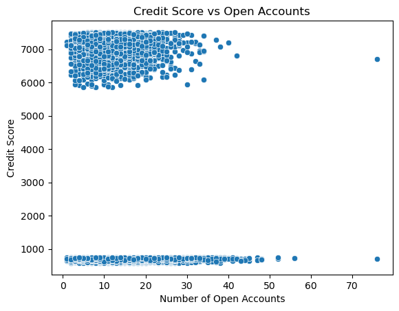

```python
sns.scatterplot(data=df, x='Number of Open Accounts', y='Credit Score')
plt.title('Credit Score vs Open Accounts')
plt.show()
```

# 21.What is the distribution of credit scores across different loan statuses?

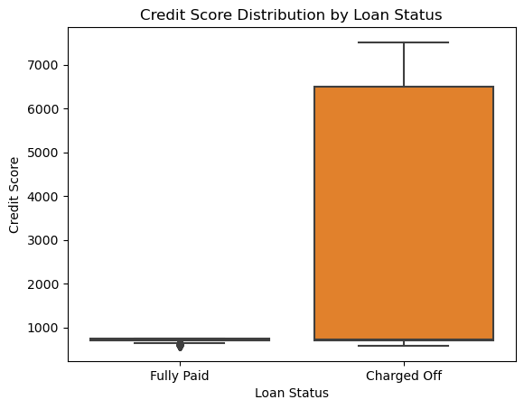

```python
sns.boxplot(data=df, x='Loan Status', y='Credit Score')
plt.title('Credit Score Distribution by Loan Status')
plt.show()
```

# 22.Is there a correlation between the current loan amount and the years of credit history?

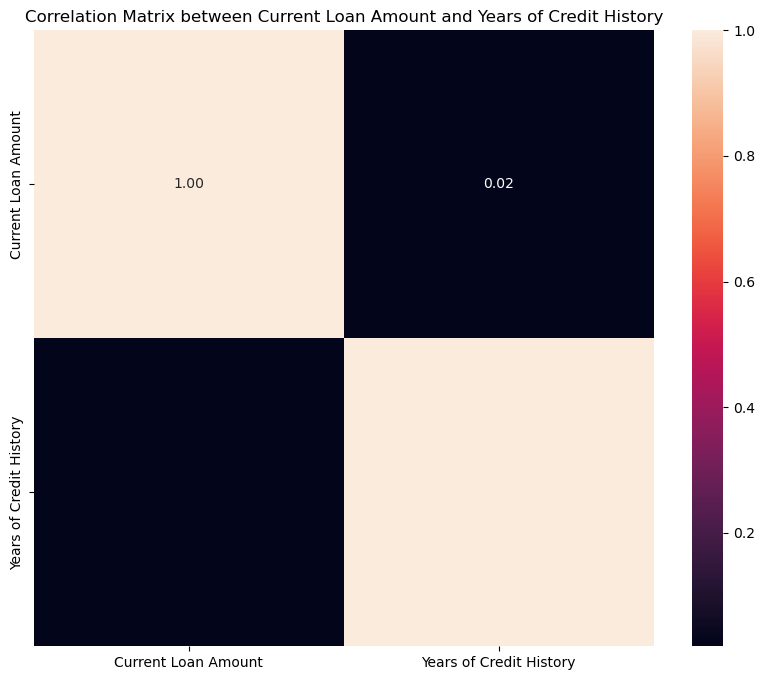

```python
df['Current Loan Amount'].corr(df['Years of Credit History'])
df[['Current Loan Amount', 'Years of Credit History']].corr()

plt.figure(figsize=(10, 8))
sns.heatmap(correlation_matrix, annot=True, fmt='.2f')
plt.title('Correlation Matrix between Current Loan Amount and Years of Credit History')
plt.show()
```

# 23.How does the monthly debt vary with the number of credit problems?

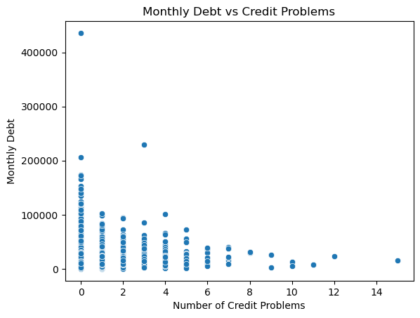

```python
sns.scatterplot(data=df, x='Number of Credit Problems', y='Monthly Debt')
plt.title('Monthly Debt vs Credit Problems')
plt.show()
```

# 24.What is the average current loan amount for each purpose of loan?

```python
df.groupby('Purpose')['Current Loan Amount'].mean().reset_index()
```

|  | Purpose | Current Loan Amount |
| --- | --- | --- |
| 0 | Business Loan | 7.837789e+06 |
| 1 | Buy House | 1.106036e+07 |
| 2 | Buy a Car | 1.414682e+07 |
| 3 | Debt Consolidation | 1.180683e+07 |
| 4 | Educational Expenses | 1.428536e+07 |
| 5 | Home Improvements | 1.252117e+07 |
| 6 | Medical Bills | 1.179902e+07 |
| 7 | Other | 1.253627e+07 |
| 8 | Take a Trip | 1.111667e+07 |
| 9 | major_purchase | 1.298956e+07 |
| 10 | moving | 1.350072e+07 |
| 11 | other | 1.059243e+07 |
| 12 | renewable_energy | 1.975534e+05 |
| 13 | small_business | 9.484232e+06 |
| 14 | vacation | 7.058680e+06 |
| 15 | wedding | 1.760299e+07 |

# 25.How does the credit score vary with the current credit balance?

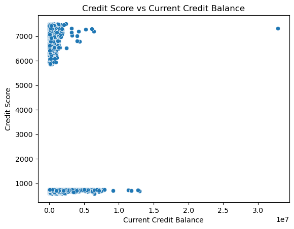

```python
sns.scatterplot(data=df, x='Current Credit Balance', y='Credit Score')
plt.title('Credit Score vs Current Credit Balance')
plt.show()
```

# 26.Is there a correlation between the annual income and the current credit balance?

```python
df['Annual Income'].corr(df['Current Credit Balance'])
df[['Annual Income', 'Current Credit Balance']].corr()
```

|  | Annual Income | Current Credit Balance |
| --- | --- | --- |
| Annual Income | 1.00000 | 0.31234 |
| Current Credit Balance | 0.31234 | 1.00000 |

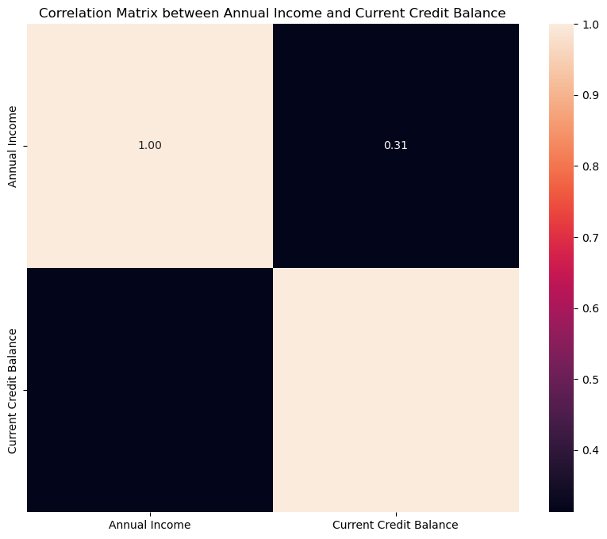

```python
plt.figure(figsize=(10, 8))
sns.heatmap(correlation_matrix, annot=True, fmt='.2f')
plt.title('Correlation Matrix between Annual Income and Current Credit Balance')
plt.show()
```

# 27.What is the distribution of annual income across different terms (short-term vs. long-term)?

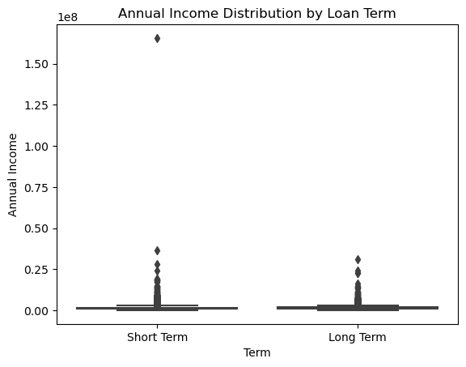

```python
sns.boxplot(data=df, x='Term', y='Annual Income')
plt.title('Annual Income Distribution by Loan Term')
plt.show()
```

# 28.How does the credit score vary with the number of credit problems?

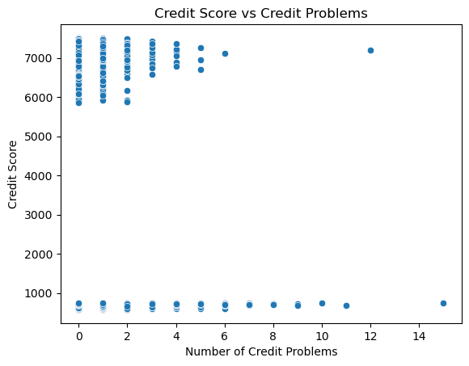

```python
sns.scatterplot(data=df, x='Number of Credit Problems', y='Credit Score')
plt.title('Credit Score vs Credit Problems')
plt.show()
```

# 29.Is there a correlation between the current loan amount and the number of credit problems?

```python
df['Current Loan Amount'].corr(df['Number of Credit Problems'])
df[['Current Loan Amount', 'Number of Credit Problems']].corr()
```

|  | Current Loan Amount | Number of Credit Problems |
| --- | --- | --- |
| Current Loan Amount | 1.000000 | -0.002795 |
| Number of Credit Problems | -0.002795 | 1.000000 |

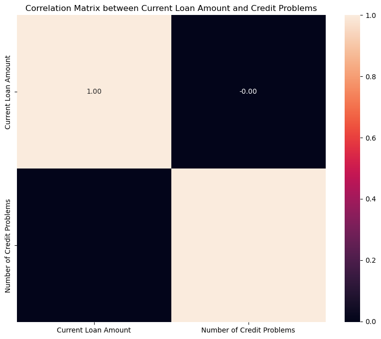

```python
plt.figure(figsize=(10, 8))
sns.heatmap(correlation_matrix, annot=True, fmt='.2f')
plt.title('Correlation Matrix between Current Loan Amount and Credit Problems')
plt.show()
```

# 30.What is the relationship between the number of open accounts and the years of credit history

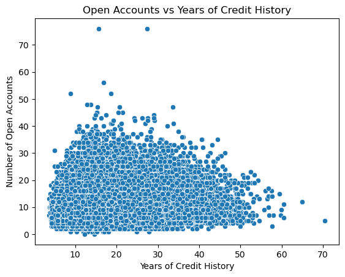

```python
sns.scatterplot(data=df, x='Years of Credit History', y='Number of Open Accounts')
plt.title('Open Accounts vs Years of Credit History')
plt.show()
```